# Meeting 8

**EMPIRICAL COVERAGE: Average coverage from simulations (“true coverage”)**

**CLAIMED COVERAGE: Size of the credible set**

**CORRECTED COVERAGE: GAM predicted coverage**

#### Empirical and Claimed Coverage Plots From Simulations Using Real-World Data

- A simulation dataset was obtained using real world minor allele frequency and linkage disequilibrium data from the UK10K project.
- The data was split into ordered and unordered datasets, with 300,000 simulations in each.

```
(Wrong) Simulation method:

1) Obtain freq, a reference haplotype matrix based on real world MAF and LD data.

2) For a fixed OR (odds ratio) and N (sample size), generate nrep (=100) posterior probability  systems.

3) For each of these, form two credible sets: one using ordered posterior probabilities and one using unordered posterior probabilities. Obtain the size (claimed coverage) and whether the CV is in the set for each credible set (covered). The same CV is chosen as causal for these systems.

4) In the form a table, report: order (whether the posterior probabilities were ordered), threshold, size, nvar (number of variants in the credible set), covered (whether the CV was in the credible set), N (sample size) and OR.

5) Replicate steps 2-4 many times for varying thresholds (0.6, 0.8, 0.9, 0.95) ORs (1.001, 1.05, 1.1, 1.15, 1.2, 1.25, 1.3) and sample sizes (N0=N1=2000, 5000, 10000, 50000).
```

- The bar charts below show the mean claimed coverage and the empirical coverage (proportion of simulations where the CV was in the set) for each odds ratio and threshold value for ordered and unordered methods. The dashed line shows the threshold in each plot.
- The error bars for coverage show the Jeffreys credible interval. This uses the Jeffreys prior (non-informative and invariant under transformation) to obtain a 95% credible interval for the posterior probabilties. Here,
  $$Prior: Beta(1/2,1/2),$$
  $$Posterior: Beta(x+1/2,n-x+1/2)$$
  where $x$ is the number of successes (covered=1) and $n$ is the number of trials (nrow(dataset)).
- The error bars for size are the 5’th and 95’th percentiles. They are asymmetric as our data is asymmetric, the value for size cannot extend beyond 1.

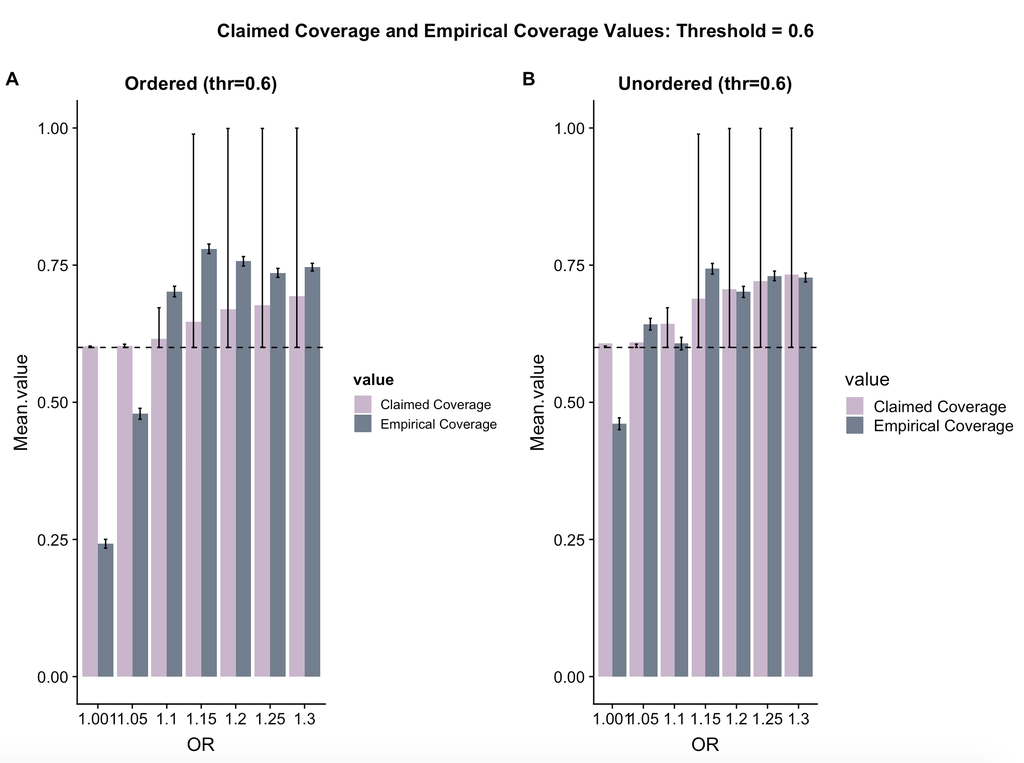

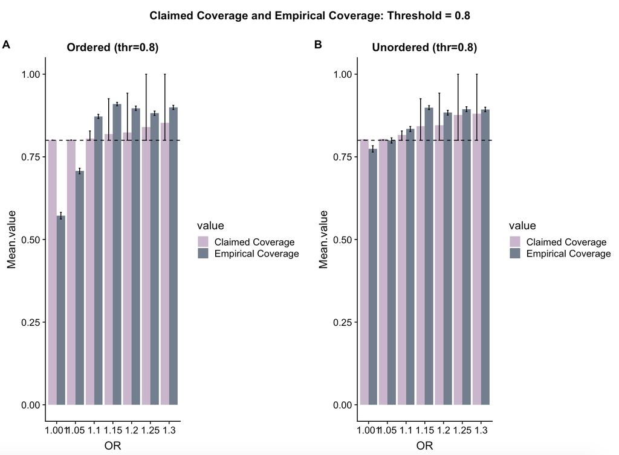

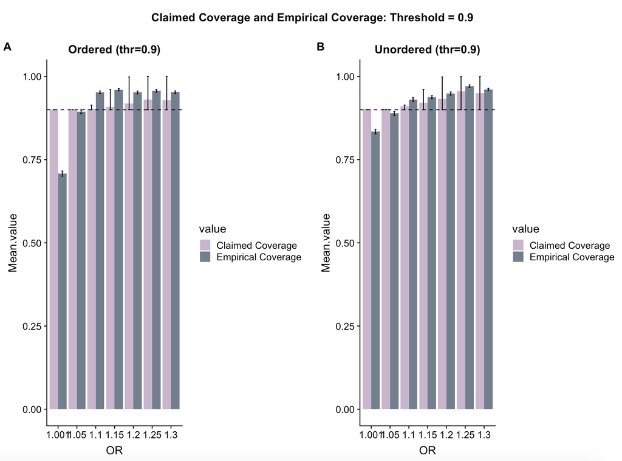

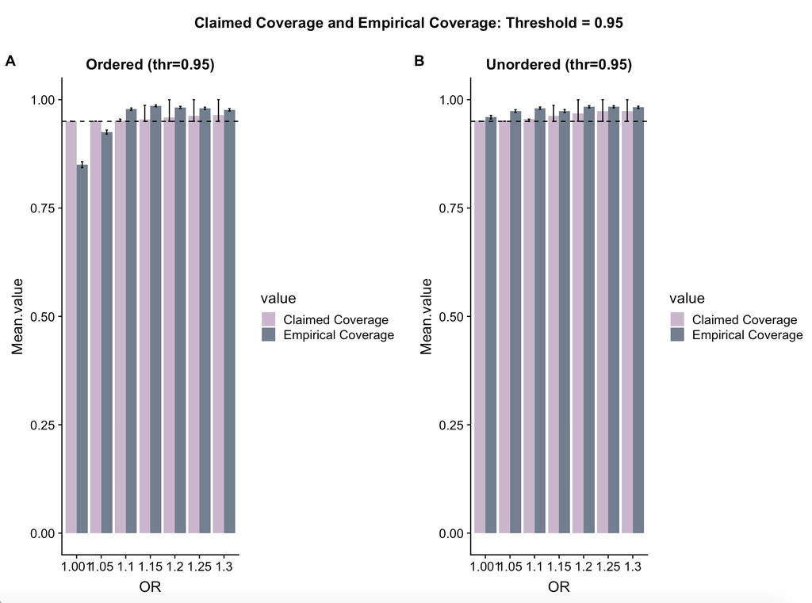

- Problem: The same CV is chosen as causal when the `simdata` function is called within `wrapper2`. This means that the same CV is causal for each 100 rows of the final simualtion dataset.
- Need to write a function which does the following to simulate data..

```
Correct Simulation method

1. Obtain freq, a reference haplotype matrix based on real-world MAF and LD data.

2. For a given OR and N, generate a posterior probability system.

3. From this, choose a random CV as causal and generate 2 credible sets, one using the ordered and one using unordered method. For each of these, report the size (claimed coverage), and whether the CV is in the set (covered).

Repeat step 1-3 many times to get a set of simulations using the ordered method, and a set of simulation using the unordered method.
```

### Predict Empirical Coverage Using Claimed Coverage

**Method: Fit different models to try and predict coverage, given claimed coverage (size), for credible sets obtained using the Bayesian approach to fine-mapping.**

- Datasets were created consisting of $x$ and $y$ co-ordinates for each SNP in a simulation. The $x$ co-ordinates are the cumulative sum of the ordered posterior probabilities (the **size**) and the $y$ co-ordinates are 0 until the causal variant is reached, after which all values are 1. This can be thought of as stepping along the $x$ axis until the causal variant is reached, when there is a step up to $y=1$ from which we continue stepping along.
- In order to obtain these co-ordinates, we consider obtaining the marginal z-scores ($Z_m$), from the joint z-scores ($Z_J$), such that,
  $$E(Z_m)=\Sigma \times Z_J,$$
  where $\Sigma$ is the correlation matrix of the genetic variants (= correlation of z-scores).
- For SNP $i$ causal, the joint effect vector is all 0s except row $i$, which is our estimate of the CVs effect.
- We can then simulate marginal z-scores from a multivariate normal disribution,
  $$Z_m^* \sim MVN(E(Z_m),\Sigma).$$
- Using these, we can use our normal approach of converting to p-values and then to posterior probabilities of association, which can be used as inputs into a function that calculates the co-ordinates described above.
- A function was written to implement this approach, ultimately obtaining these co-ordinates.

```r
cali.func <- function(Zj, CV, Sigma, nrep, N, maf){
  exp.zm=Zj%*%Sigma # find marginals given joint
  zstar=rmvnorm(nrep,exp.zm,Sigma) # simulate z scores from mvnorm
  pstar=pnorm(abs(zstar),lower.tail=FALSE)*2 # calculate p values

  ppstar <- lapply(1:nrow(zstar), function(i) {
    tmp <- coloc:::approx.bf.p(p = pstar[i,],
                               f=maf, type = "cc", N=N, s=0.5)[,"lABF"]
    p1 <- 1e-04 # hard coded - bad code - can fix later
    nsnps <- length(tmp)
    prior <- c(1-nsnps*p1,rep(p1,nsnps))
    tmp <- c(1,tmp) # add on extra for null model
    my.denom <- coloc:::logsum(tmp + prior)
    tmp1 <- exp(tmp - my.denom)[-1] # drop null again
    tmp1/sum(tmp1) # ensure pps sum to 1
  }) # simulated posterior probabilities - list of dataframes

  lapply(ppstar, function(pp=ppstar,CV=1){
    o = order(pp,decreasing=TRUE)
    x = cumsum(pp[o]) # size
    y = cumsum(o==CV) # 0 until CV reached, then 1
    return(data.frame(x,y))
  })
}
```

- The output of this function is a list of $nrep$ dataframes consisting of $nsnp (=100)$ $x$ and $y$ co-ordinates.
- We considered merging all of the co-ordinates and fitting a generalised linear model, in order to obtain the calibration curve relating claimed coverage to empirical coverage.
- When testing these calibration curves on new posterior probability systems obtained from the exact same distribtuion, they did not perform well.

**Finding: Sigmoid calibration curves obtained from logistic regressions do not allow us to estimate empirical coverage from claimed coverage.**

- Consequently, different models were considered to try and obtain a more robust calibration curve, including random forest and GAM models.
- We found that the random forest method performed well on held out data, and that its predicted coverage was closest to the true coverage. However, the fit is very noisy and therefore much larger datasets are required to use this model. We sought to find a more efficient method.
- GAM logistic models were considered. GAM models allow the predictor to be written in terms of multiple linear/non-linear additive terms. This therefore captures various non-linear effects of the predictor on the response. Hence, the predictors “depend linearly or non linearly on some smooth non linear functions like splines, polynomials or step functions etc”. The regression equation looks like,
  $$f(x_i)=y=\alpha+f_1(x_{i1})+f_2(x_{i2})+...+f_p(x_{ip})+\epsilon.$$
- In order to test out the accuracy of this GAM model, we considered a leave-one-out approach, which incorporated a threshold value.

```r
library(magrittr)
library(data.table)
d <- lapply(d, as.data.table) # d is dataset obtained by cali.func above

# make a size/coverage summary at specific threshold
f <- function(dd,thr) {
    wh <- which(dd$x>thr)[1]
    dd[wh,] # size of cred set
}
a1 <- lapply(d,f,thr=0.5)  %>% rbindlist() # a1 is dataframe of size and covered                                                                    for cred sets obtained from each nrep of cali.func

# gam model fitted to LOO data
library(mgcv)

invlogit <- function(x) exp(x)/(1+exp(x))
pred <- numeric(nrow(a1)) # empty vector to fill with predictions
for(i in 1:nrow(a1)) {
    m1 <- gam(y ~ s(x), data=a1[-i,], family="binomial") # GAM model
    pred[i] <- invlogit(predict(m1,newdata=a1[i,]))
}
mean(pred)
mean(a1$y)
```

- `Pred` is a vector of predicted coverage for credible sets obtained for each $nrep$ of `cali.func`. `a1$y` is a vector of 0s and 1s which indicate if the CV was in the credible set, the ‘contained’ column in our previous work.
- We compare the mean of these two vectors and find that they are extremely close, indicating that this GAM method may be accurate in predicting coverage.
- The following table summarises the results using this method on different datasets. This is for varying LD blocks and marginal effect sizes for the CV.
- emp.cov is the mean of the covered column (i.e. the empirical coverage) and corrected.cov is the mean of the predicted coverage values obtained using the GAM model approach. The last two columns show the 5th and 95th percentile.

```
##   emp.cov corrected.cov       low       upp
## 1    0.73     0.7267016 0.6883424 0.7662405
## 2    0.79     0.7890582 0.7600271 0.8442997
## 3    0.88     0.8669479 0.7381942 0.9933964
## 4    0.98     0.9796385 0.8794017 1.0000000
## 5    1.00     1.0000000 1.0000000 1.0000000
## 6    0.68     0.6869433 0.6189254 0.7479444
```

```
##     emp.cov       corrected.cov         low              upp
##  Min.   :0.6600   Min.   :0.6552   Min.   :0.4664   Min.   :0.7479
##  1st Qu.:0.8000   1st Qu.:0.8001   1st Qu.:0.6820   1st Qu.:0.8975
##  Median :0.9000   Median :0.8938   Median :0.7816   Median :0.9735
##  Mean   :0.8787   Mean   :0.8779   Mean   :0.7781   Mean   :0.9382
##  3rd Qu.:0.9600   3rd Qu.:0.9599   3rd Qu.:0.8859   3rd Qu.:0.9988
##  Max.   :1.0000   Max.   :1.0000   Max.   :1.0000   Max.   :1.0000
```

- In all datasets, we see that pred.cov is very close to the true coverage. Below shows a plot of these results.

**Nb, error bars not put on because there are points on top of eachother??**

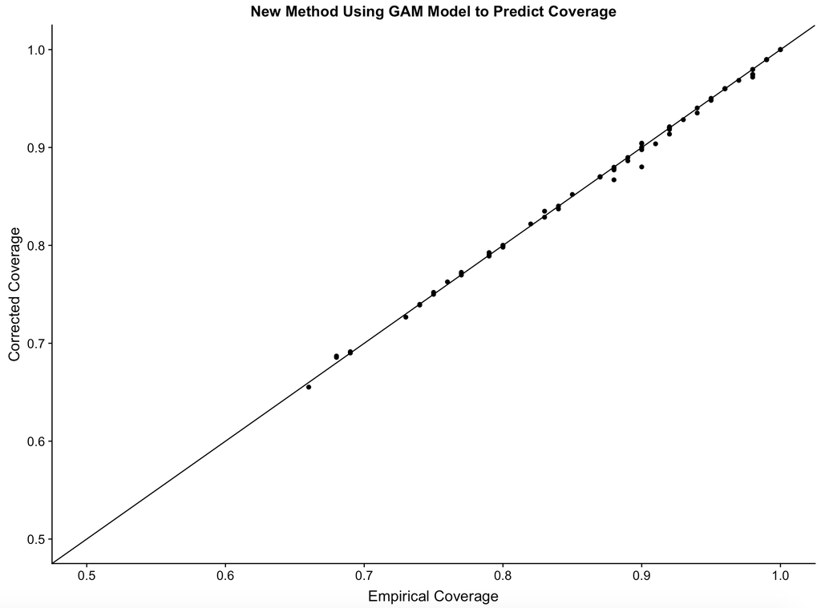

### Application of Approach When True CV Unknown

- We now consider how this approach can be used in the real-world, where the CV is unknown.
- Code is written to implement this approach for each SNP being the causal SNP.
- We then wish to average over these to obtain a calibration curve where we can read off claimed coverage and get a value for corrected coverage.
1. Assume there are 100 SNPs in our system which we are considering. We want to obtain the marginal given the joint for each SNP being causal. The joint effect for SNP $i$ being causal is a vector of 100 0’s except entry $i$ which is the observed effect of that SNP.

```r
### Code to get the joint effect vectors for each SNP being causal
temp <- diag(x = 4, nrow = 100, ncol = 100)
zj <- do.call(c, apply(temp, 1, list))
```

**You’ve said to set this to the observed Z score from one simulated dataset whose credset needs adjusting. Is this from the sim_z_score function in GWAS? If so, then this requires specification of the CV. Do I do this and then just pretend I don’t know it?**

2. We obtain 100 $E(Z_m)$ vectors by multiplying each $Z_J$ by $\Sigma$.
3. From each of these we can simulate $Z_m^*\sim MVN(E(X_J),\Sigma)$. Each row of $Z_m^*$ is a simulation whereby the columns represent the marginal effects of the SNPs. At this stage, we have 100 lists (one for each SNP being causal) of $100*100$ matrices (rows=100 simulations, columns=100 SNPs).
4. For each simulation in each list, obtain the posterior probabiltiy system.

```r
pp.func <- function(Zj, thr=0.6){
  exp.zm=Zj%*%Sigma
  zstar=rmvnorm(100,exp.zm,Sigma)
  pstar=pnorm(abs(zstar),lower.tail=FALSE)*2 # calculate p values

  ppstar <- lapply(1:nrow(zstar), function(i) {
    tmp <- coloc:::approx.bf.p(p = pstar[i,],
                               f=maf, type = "cc", N=5000, s=0.5)[,"lABF"]
    p1 <- 1e-04 # hard coded - bad code - can fix later
    nsnps <- length(tmp)
    prior <- c(1-nsnps*p1,rep(p1,nsnps))
    tmp <- c(1,tmp) # add on extra for null model
    my.denom <- coloc:::logsum(tmp + prior)
    tmp1 <- exp(tmp - my.denom)[-1] # drop null again
    tmp1/sum(tmp1) # ensure pps sum to 1
  })
}

pps.tmp <- lapply(zj,pp.func) # 100 lists of 100 lists, need to rbind first 100 then second 100 etc
pps <- lapply(pps.tmp, function(sub_list) {
  do.call(rbind, sub_list)
})
# pps is 100 lists of 100*100 matrix (rows is samples, columns is SNP)
```

5. For a given threshold, obtain the credible set using the normal method and report the size (claimed coverage) and whether the CV is present. At this stage, we have 100 lists of $100*2$ dataframes, the claimed.cov column is the size of the credible set obtained from the simulation and the covered column is whether the CV is in the credible set. There are 100 rows for each $Z_M^*$ sample.

```r
credset <- function(pp, CV, thr=0.6) {
  o <- order(pp,decreasing=TRUE) # order index for true pp
  cumpp <- cumsum(pp[o]) # cum sums of ordered pps
  wh <- which(cumpp > thr)[1] # how many needed to exceed thr
  size <- cumpp[wh]
  contained=as.numeric(CV %in% o[1:wh])
  data.frame(claimed.cov=size, covered=contained)
}

n_pps <- length(pps)
args <- 1:100

d5 <- lapply(1:n_pps, function(x){
  apply(pps[[x]],1,credset,args[x]) %>% rbindlist()
})
# d5 is 100 lists of the size of the cred set and covered for each simulation
```

6. Used these claimed coverage values as predictors in the leave-one-out GAM model approach to predict coverage, obtaining a corrected coverage value.

```r
invlogit <- function(x) exp(x)/(1+exp(x))

pred <- numeric(nrow(d5[[1]]))

mean.func <- function(x){
  for(i in 1:nrow(x)) {
    m5 <- gam(covered ~ s(claimed.cov), data=x[-i,], family="binomial")
    pred[i] <- invlogit(predict(m5,newdata=x[i,]))
  }
  data.frame(corrected.ave.cov=mean(pred),true.cov=mean(x$covered))
}

means <- lapply(d5,mean.func)
```

7. Save the GAM model output. We now have 100 GAM model outputs, for 100 SNPs each being considered as causal. Weight these by the posterior probability of that SNP being causal to obtain a final calibration curve.

### Questions

- Need to change simulation code… No idea how to do this to get the simulations we want.

```r
library(magrittr)
library(data.table)
library(simGWAS)
#if (!requireNamespace("BiocManager", quietly = TRUE))
# install.packages("BiocManager")
#BiocManager::install("snpStats", version = "3.8")
library(snpStats)
library(coloc)


cor2 <- function (x)
{
  1/(NROW(x) - 1) * crossprod(scale(x, TRUE, TRUE))
}

args <- list(ncse=5000,nctl=5000,hyp="h3",nreps=5)

## real data from UK10K
file.ldd="/home/cew54/share/Data/reference/lddetect/EUR/fourier_ls-chr22.bed"
file.vcf="/home/cew54/share/Data/reference/UK10K/BCF/chr22.bcf.gz"

## ldblocks
ldd <- fread(file.ldd)

## split bcf by ldblocks
ldd[,blocknum:=1:.N]
ldd[,dist:=stop-start]
ldd[,comm:=paste0("/home/cew54/share/bin/bcftools view ",file.vcf,
                  " --min-af 0.02:minor --max-alleles 2 --min-alleles 2 ",
                  " -r chr",22,":",start,"-",stop," -Ov ")] # -o ",tmp)]
gethap <- function(i) {
  y=fread(ldd$comm[i])
  ha <- simGWAS:::vcf2haps(as.matrix(y[,-c(1:9)]))
  rownames(ha) <- paste0("pos",y$POS)
  t(ha)
}

block <- sample(which(ldd$dist < 1.2e+6),1) # use smallest LD block to be fast
h <- gethap(block) # rows=samples, cols=snps
use <- apply(h,2,var)>0 & colMeans(h) > 0.01 & colMeans(h)<0.99  # no monomorphs
h <- h[,use,drop=FALSE]
nmax <- 1000 # keep this small to make simulations fast
if(ncol(h)>nmax) {
  start <- sample(1:(ncol(h)-nmax),1)
  h <- h[,start:(start+nmax-1)]
} ## max 1000 snps, for speed in simulations
maf <- colMeans(h)
LD <- cor2(h)

freq <- as.data.frame(h+1)
freq$Probability <- 1/nrow(freq)
snps <- colnames(freq)[-ncol(freq)]

simdata <- function(freq,OR=1.1,nrep=100,N0=2000,N1=2000,MAF=maf) {
  snps <- colnames(freq)[-ncol(freq)] # snp names
  iCV=sample(length(maf) ,1)
  CV=snps[iCV]

  FP <- make_GenoProbList(snps=snps,W=CV,freq=freq)
  zsim <- simulated_z_score(N0=N0, # number of controls
                            N1=N1, # number of cases
                            snps=snps,
                            W=CV, # causal variants, subset of snps
                            gamma.W=log(OR), # log odds ratios
                            freq=freq, # reference haplotypes
                            nrep=nrep)
  psim <- 2*pnorm(-abs(zsim)) # generate p values from z values

  # Generate posterior probabilities using finemap.abf function
  ppsim <- lapply(1:nrow(zsim), function(i) {
    tmp <- coloc:::approx.bf.p(p = psim[i,],
                               f=maf, type = "cc", N=N0+N1, s=N0/(N1+N0))[,"lABF"]
    p1 <- 1e-04 # hard coded - bad code - can fix later
    nsnps <- length(tmp)
    prior <- c(1-nsnps*p1,rep(p1,nsnps))
    tmp <- c(1,tmp) # add on extra for null model
    my.denom <- coloc:::logsum(tmp + prior)
    tmp1 <- exp(tmp - my.denom)[-1] # drop null again
    tmp1/sum(tmp1)
  })  %>% do.call("rbind",.) # simulated posterior probabilities
  return(list(ppsim=ppsim,CV=CV,iCV=iCV))
}

credset <- function(pp, causal, thr=0.9,do.order=TRUE) {
  o <- if(do.order) {
    order(pp,decreasing=TRUE)
  } else {
    seq_along(pp)
  }

  cumpp <- cumsum(pp[o])

  ## which is the first snp s t cumsum > 0.9
  wh <- which(cumpp > thr)[1]
  wh

  ## these are the variants in the cred set
  credset <- o[1:wh]

  return(list(credset=credset,
              thr=thr,
              size=sum( pp[credset] ),
              contained=causal %in% credset))
}

wrapper2_x <- function(...) {
  n <- 5000 # or can vary sample size too
  or <- sample(c(1.001,1.05,1.1,1.15,1.2,1.25,1.3),1) # vary or
  thr <- sample(c(0.6,0.8,0.9,0.95),1) # vary threshold
  data <- simdata(freq, OR=or, N0=n, N1=n, MAF=maf) # data is a list of data.frames
  ppsim <- lapply(1:nrow(data$ppsim), function(i) data$ppsim[i,])

  cs <- lapply(ppsim, function(d) {
    tmp.ord <- credset(d, data$iCV, thr=thr)
    tmp.noord <- credset(d, data$iCV, thr=thr, do.order=FALSE)

    data.frame(order=c(TRUE,FALSE),
               thr=tmp.ord$thr,
               size=c(tmp.ord$size,tmp.noord$size),
               nvar=c(length(tmp.ord$credset),
                      length(tmp.noord$credset)),
               covered=c(tmp.ord$contained,
                         tmp.noord$contained))
  })
  cs <- do.call("rbind",cs)
  cs$N <- n
  cs$OR <- or
  cs$thr <- thr
  cs
}

test1 <- replicate(100,wrapper2_x(),simplify = FALSE)
sims1 <- data.table::rbindlist(test1, idcol=FALSE)

sims_ord <- sims1[order=="TRUE"] # separate ordered and non-ordered simulations
sims_noord <- sims1[order=="FALSE"]

saveRDS(sims_ord, "sims.ord.RDS")
saveRDS(sims_noord, "sims.noord.RDS")
```

- GAM method when CV is unknown?